# ECO634- Lab 5

Mercy Melo

# Functions and Datasets Required for Exercise

```r
#Define linear function
line_point_slope = function(x, x1, y1, slope)
{
  get_y_intercept =
    function(x1, y1, slope)
      return(-(x1 * slope) + y1)
  linear =
    function(x, yint, slope)
      return(yint + x * slope)
  return(linear(x, get_y_intercept(x1, y1, slope), slope))
}

#Define exponential function
exp_fun = function(x, a, b)
{
  return(a * exp(-b * x))
}

#Define Ricker function
ricker_fun = function(x, a, b)
{
  return(a * x * exp(-b * x))
}

#Importing Salamander Data
require(here)
disp <- read.csv(here("data", "dispersal.csv"))
```

# Question 1

Show the R code you used to create exp_fun()

```r
exp_fun = function(x, a, b)
{
  return(a * exp(-b * x))
}
```

# Question 2

Create a single figure containing 4 exponential curves using provided parameter values

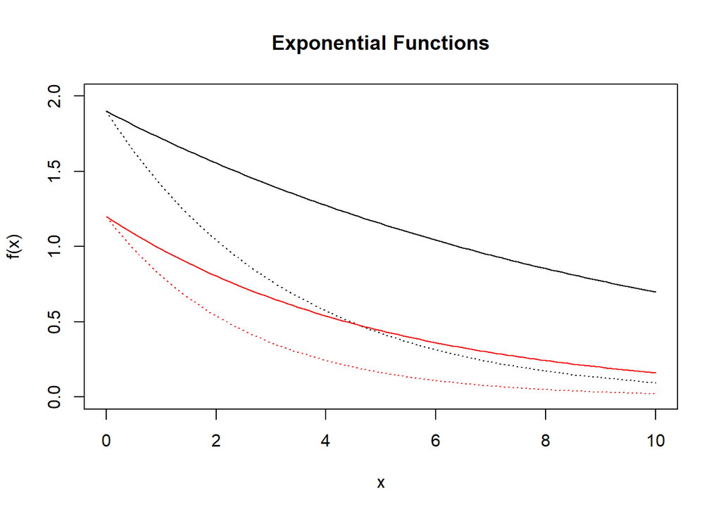

```r
{
  curve(
  exp_fun(x, 1.9, 0.1),
  from = 0, to = 10, add = FALSE,
  col = "black", lty = "solid",
  xlim = c(0,10), ylim = c(0,2),
  main = "Exponential Functions",
  ylab = "f(x)", xlab = "x")

curve(
  exp_fun(x, 1.9, 0.3),
  from = 0, to = 10, add = TRUE,
  col = "black", lty = "dotted")

curve(
  exp_fun(x, 1.2, 0.2),
  from = 0, to = 10, add = TRUE,
  col = "red", lty = "solid")

curve(
  exp_fun(x, 1.2, 0.4),
  from = 0, to = 10, add = TRUE,
  col = "red", lty = "dotted")
}
```

# Question 3

Observe how the curves vary as you change the two parameters’ values. Qualitatively describe what happens to the curve as you vary parameter a

As you vary parameter a, the vertical position of the curve changes such that the f(x) value at x = 0 (the y-intercept of the above plots) is different based on a’s value. Higher values of a will shift the curve upwards while lower value of a will shift the curve downwards. The slope of the curve alters slightly with a changing a value, but that appears to be a side-effect of the vertical positioning shift.

# Question 4

Observe how the curves vary as you change the two parameters’ values. Qualitatively describe what happens to the curve as you vary parameter b

As you vary parameter b, the slope of the curve changes dramatically, but the “y-intercept” remains the same. This results in two curves of differing b values beginning at the same x = 0 value, but then diverging based on the value of b. Larger b values produce steeper slopes that reach an f(x) = 0 value much more quickly than smaller b values.

# Question 5

Create a single figure containing 6 Ricker curves using provided parameter values

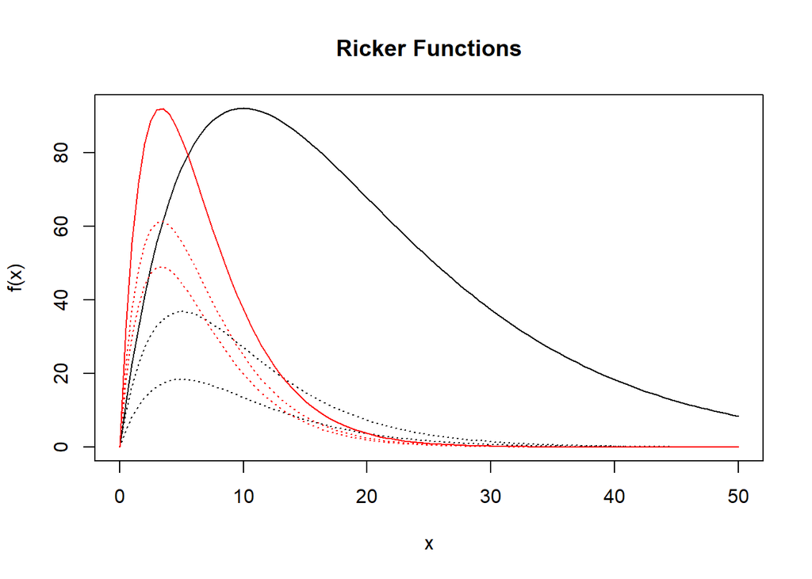

```r
{
  curve(
  ricker_fun(x, 25, 0.1),
  from = 0, to = 50, add = FALSE,
  col = "black", lty = "solid",
  main = "Ricker Functions",
  ylab = "f(x)", xlab = "x")

curve(
  ricker_fun(x, 20, 0.2),
  from = 0, to = 50, add = TRUE,
  col = "black", lty = "dotted")

curve(
  ricker_fun(x, 10, 0.2),
  from = 0, to = 50, add = TRUE,
  col = "black", lty = "dotted")

curve(
  ricker_fun(x, 75, 0.3),
  from = 0, to = 50, add = TRUE,
  col = "red", lty = "solid")

curve(
  ricker_fun(x, 50, 0.3),
  from = 0, to = 50, add = TRUE,
  col = "red", lty = "dotted")

curve(
  ricker_fun(x, 40, 0.3),
  from = 0, to = 50, add = TRUE,
  col = "red", lty = "dotted")
}
```

# Question 6

Observe how the curves vary as you change the two parameters’ values. Qualitatively describe what happens to the curve as you vary parameter a

As you vary parameter a, the height of the highest point in the curve changes in response. Larger values of a produce taller peaks in this high-point and smaller values of a produce shorter peaks. Both curves appear to have the same slope, same peak width, and follow the same general pattern despite the change in peak height.

# Question 7

Observe how the curves vary as you change the two parameters’ values. Qualitatively describe what happens to the curve as you vary parameter b

As you vary parameter b, the width and height of the peak of the curve changes. The b parameter seems to limit the overall size of the peak in this manner with larger b values producing shorter and narrower peaks while smaller b values produce wider and taller peaks.

# Question 8

Linear Model: Provide the values of the slope and intercept parameters you chose. Briefly describe how you chose the values.

I chose a slope of -0.001 and a point intercept of (300, 0.65). To find these values, I began by creating a scatterplot of the salamander data using distance class on the x-axis and dispersal rate of new breeders on the y-axis. I thought of what general line would best fit the data and chose a point within that line to derive my intercept values from (I just approximated the values from the axes). I then calculated an approximate slope by choosing another point on my imaginary line and calculating (y2-y1)/(x2-x1). This gave me a very small value for slope, so I played around with small values until I got the desired fit.

# Question 9

Include a scatterplot of the salamander data with your fitted linear model.

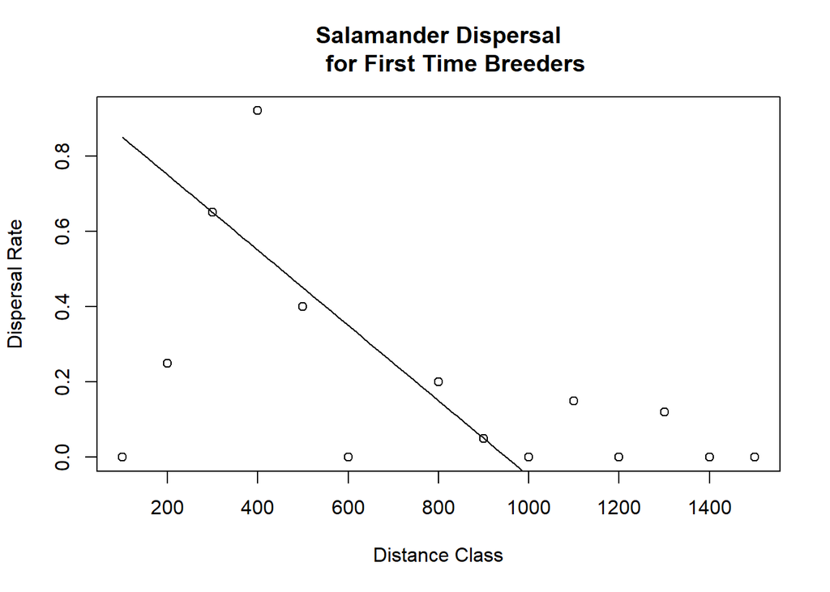

```r
plot(disp$dist.class, disp$disp.rate.ftb,
     main = "Salamander Dispersal
     for First Time Breeders",
     ylab = "Dispersal Rate",
     xlab = "Distance Class")
curve(
  line_point_slope(x, 300, 0.65, -0.001),
  add = TRUE)
```

# Question 10

# Question 11

Include a scatterplot of the salamander data with your fitted exponential model.

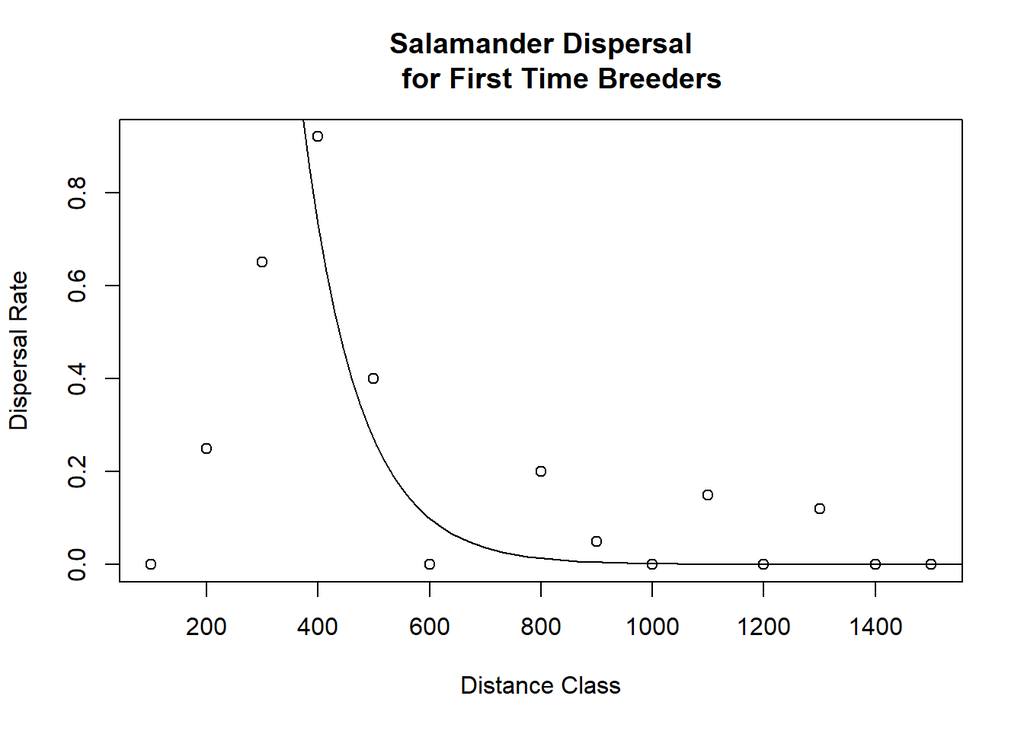

```r
plot(disp$dist.class, disp$disp.rate.ftb,
    main = "Salamander Dispersal
     for First Time Breeders",
     ylab = "Dispersal Rate",
     xlab = "Distance Class")
curve(
  exp_fun(x, 40, 0.01),
  from = 100, to = 1600, add = TRUE,
  col = "black", lty = "solid")
```

# Question 12

Ricker Model: Provide the values of the a and b. Briefly describe how you chose the values.

I chose a value of 0.01 for a and 1/240 for b. It was a challenge to find these values, but I took the approach of beginning with mostly random values and altering them until I was able to see the curve in my plot window (I originally had a set way too large and was unable to see the curve- it just looked like an exponential function). Once I was able to see the curve, I adjusted my a value to fit my desired vertical height and adjusted my b value to determine the width of the curve.

# Question 13

Include a scatterplot of the salamander data with your fitted ricker model.

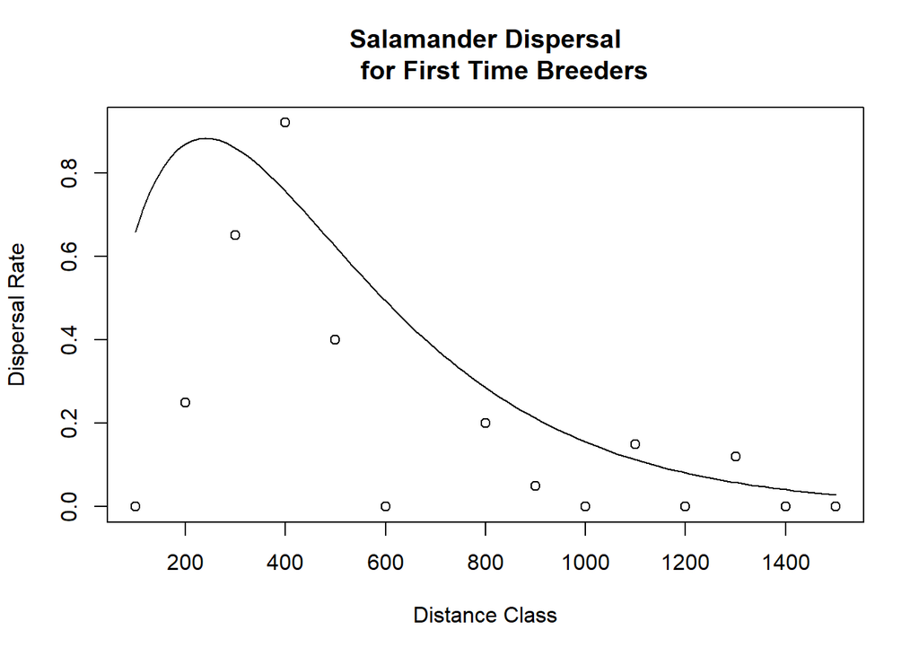

```r
plot(disp$dist.class, disp$disp.rate.ftb,
    main = "Salamander Dispersal
     for First Time Breeders",
     ylab = "Dispersal Rate",
     xlab = "Distance Class")
curve(
  ricker_fun(x, 0.01, 1/240),
  from = 100, to = 1500, add = TRUE,
  col = "black", lty = "solid")
```

# Question 14

Show the R code you used to create your data frame of model residuals.

```r
#For linear model
y_pred_lin = line_point_slope(disp$dist.class, 300, 0.65, -0.001)
resids_linear <- disp$disp.rate.ftb - y_pred_lin

#For exponential model
y_pred_exp = exp_fun(disp$dist.class, 40, 0.01)
resids_exp <- disp$disp.rate.ftb - y_pred_exp

#For Ricker model
y_pred_rick = ricker_fun(disp$dist.class, 0.01, 1/240)
resids_ricker <- disp$disp.rate.ftb - y_pred_rick

#Adding all residuals into a dataframe
resids_data_frame <- data.frame(resids_linear, resids_exp, resids_ricker)
head(resids_data_frame)
```

```
##   resids_linear   resids_exp resids_ricker
## 1 -8.500000e-01 -14.71517765    -0.6592406
## 2 -5.000000e-01  -5.16341133    -0.6191964
## 3  1.110223e-16  -1.34148273    -0.2095144
## 4  3.700000e-01   0.18737444     0.1644976
## 5 -5.000000e-02   0.13048212    -0.2225724
## 6 -3.500000e-01  -0.09915009    -0.4925100
```

# Question 15

Include histograms of the residuals for each of your three models.

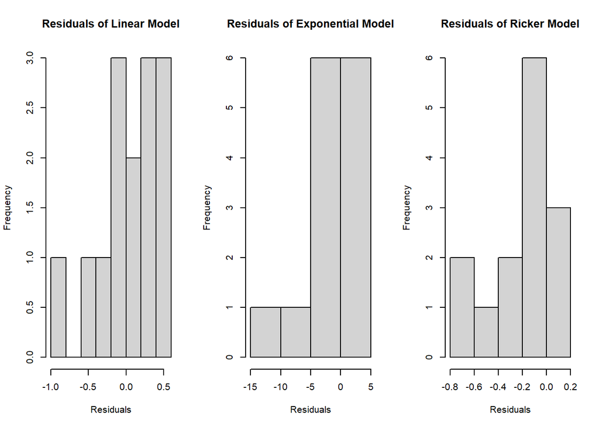

```r
par(mfrow = c(1, 3))
hist(resids_linear, main = "Residuals of Linear Model",
     xlab = "Residuals", ylab = "Frequency")
hist(resids_exp, main = "Residuals of Exponential Model",
     xlab = "Residuals", ylab = "Frequency")
hist(resids_ricker, main = "Residuals of Ricker Model",
     xlab = "Residuals", ylab = "Frequency")
```